# **Phacelia hastata** *Filtering workflow & exploration of parameters*

Initially filtering on 3 things:

- SNPs only (no indels) `--remove-indels`
- biallelic sites only `--min-alleles 2` and `--max-alleles 2`
- 1 SNP per contig (helps account for LD, our reads are typically <100 BP length) `--thin 100`
- **OPTIONAL (but I typically do)** - filter on call quality. Our call qualities are typically very good so it doesn’t get rid of much but might as well cut out the worst stuff `--minQ 30`

```bash
vcftools \
--gzvcf PHHA.vcf.gz \
--remove-indels \
--min-alleles 2 \
--max-alleles 2 \
--thin 100 \
--minQ 30 \
--remove-filtered-all \
--recode \
--recode-INFO-all \
--out PHHA.bithin.q30
```

Produces file **PHHA.bithin.q30.recode.vcf**

Making a summary file to look at individual missingness

```bash
vcftools \
--vcf PHHA.bithin.q30.recode.vcf \
--missing-indv \
--out PHHA.bithin.q30
```

Produces file called **PHHA.bithin.q30.imiss**

**239 of 239 individuals**

**645,604 SNPs**

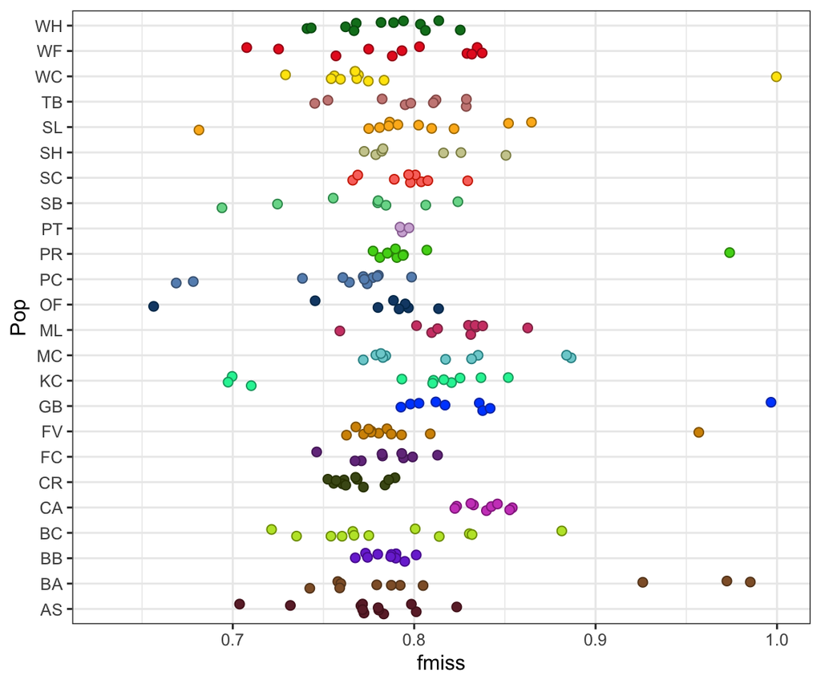

Just looking for some natural breaks here. Wanting to remove individuals that look like obvious outliers without drastically cutting certain populations or lowering within-population sampling.

Below showing individual totals for each population based on **0.85** threshold.

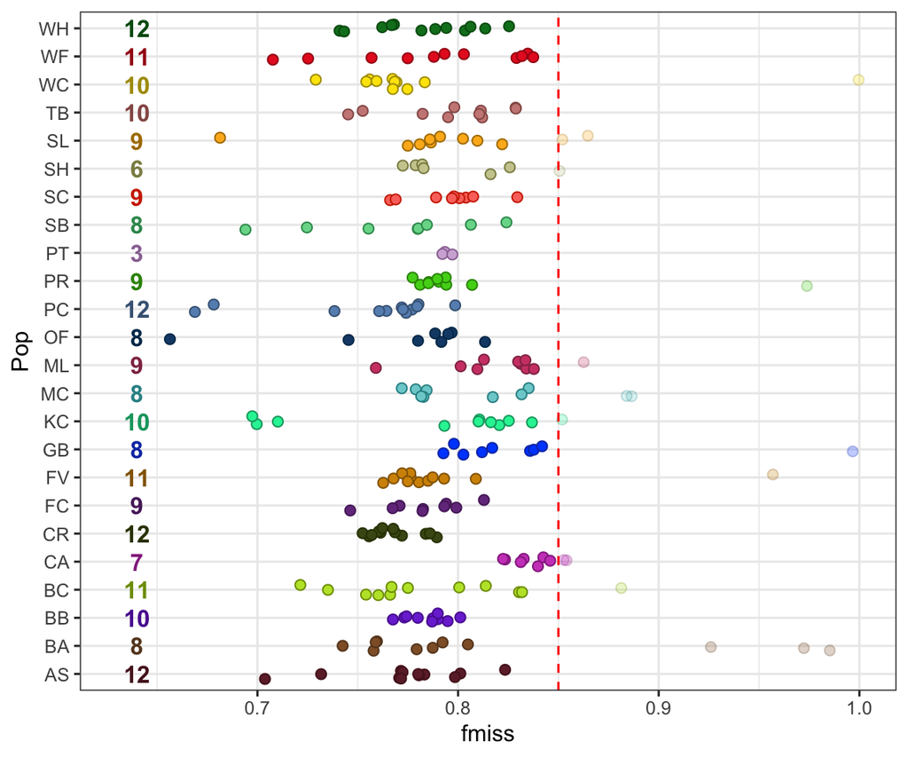

Removing the selected individuals via:

```bash
awk '$5 > 0.85 {print $1}' PHHA.bithin.q30.imiss | tail -n +2 > indmiss85.txt
```

Now filtering out those identified individuals and making a downsized VCF.

```bash
vcftools \
--vcf PHHA.bithin.q30.recode.vcf \
--remove indmiss85.txt \
--remove-filtered-all \
--recode \
--recode-INFO-all \
--out PHHA.bithin.q30.i85
```

Next taking a look at depth, particularly to set a maximum loci depth. Need to get two different output files.

```bash
vcftools \
--vcf PHHA.bithin.q30.i85.recode.vcf \
--site-mean-depth \
--out PHHA.bithin.q30.i85
```

```bash
vcftools \
--vcf PHHA.bithin.q30.i85.recode.vcf \
--freq2 \
--out PHHA.bithin.q30.i85
```

Produces files called **PHHA.bithin.q30.i85.ldepth.mean** and **PHHA.bithin.q30.i85.frq**

Individual depth (averaged across all loci). Filtered out individuals >85% missigness as identified above. Calculating an *adjusted depth* that is corrected for the rate at which loci are missing in certain individuals.

**222 of 239 individuals**

**645,604 SNPs**

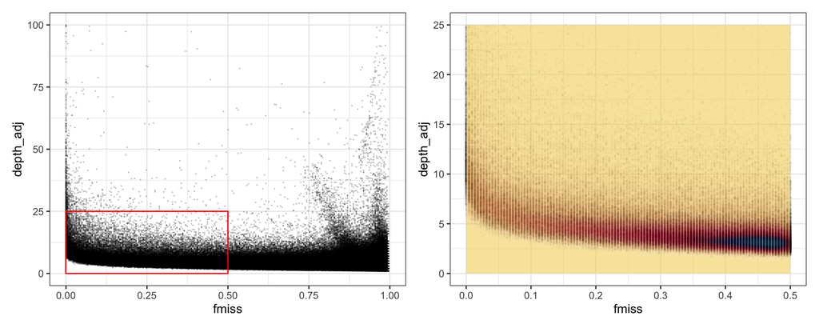

```r
var_depth <- read_delim("../filtering/PHHA.bithin.q30.i85.ldepth.mean", delim = "\t",
           col_names = c("chr", "pos", "mean_depth", "var_depth"), skip = 1)

a_freq <- read_delim("../filtering/PHHA.bithin.q30.i85.frq", delim = "\t",
                     col_names = c("chr", "pos", "nalleles", "nchr", "a1", "a2"), skip = 1) %>%
  mutate(fmiss = (max(nchr)-nchr)/max(nchr))

full_depth <- full_join(var_depth, a_freq, by = c("chr", "pos")) %>%
  # re-calculating depth to adjust for missingness
  # this represents mean depth only across individuals for which there is data
  # makes depth more directly comparable, decouples from coverage across individuals
  mutate(depth_adj = mean_depth*(1/(1-fmiss)))

colors <- moma.colors('OKeeffe', type = 'continuous', n = 200)

adpth_all <- ggplot(full_depth, aes(x = fmiss, y = depth_adj)) +
  geom_point(alpha = 0.25, pch = 16, size = 0.3, color = 'black') +
  annotate(geom = 'rect', color = 'red', linewidth = 0.5,
           xmin = -0.001, xmax = 0.5, ymin = 0, ymax = 25, fill = 'transparent') +
  scale_y_continuous(limits = c(0, 100)) +
  theme_bw() +
  theme(legend.position = 'none')

var_adj <- ggplot(full_depth, aes(x = fmiss, y = depth_adj)) +
  geom_point(alpha = 0.05, pch = 16, size = 0.6, color = 'black') +
  geom_density_2d_filled(alpha = 0.6, bins = 200, contour_var = 'count') +
  scale_fill_manual(values = colors) +
  scale_y_continuous(limits = c(0, 25)) +
  scale_x_continuous(limits = c(0, 0.5)) +
  theme_bw() +
  theme(legend.position = 'none')

adpth_all + var_adj
```

Going to extract loci below mean depth (adjusted) of **12**. Doing manually and creating a file of sites to filter for (include) in `vcftools`.

```r
snp_set <- filter(full_depth, depth_adj < 12) %>%
  select(chr, pos)

write_delim(snp_set, '../filtering/sites_maxdp12.tsv', delim = '\t', col_names = F)
```

Creating another downsized VCF with only those sites.

**222 individuals**

**633,261 SNPs**

```bash
vcftools \
--vcf PHHA.bithin.q30.i85.recode.vcf \
--positions sites_maxdp12.tsv \
--remove-filtered-all \
--recode \
--recode-INFO-all \
--out PHHA.bithin.q30.i85.maxdp12
```

Next looking at SNP retention across parameters of **allelic missingness** and **MAF**. This figure shows how many SNPs would pass filtering based on combinations of these two parameters.

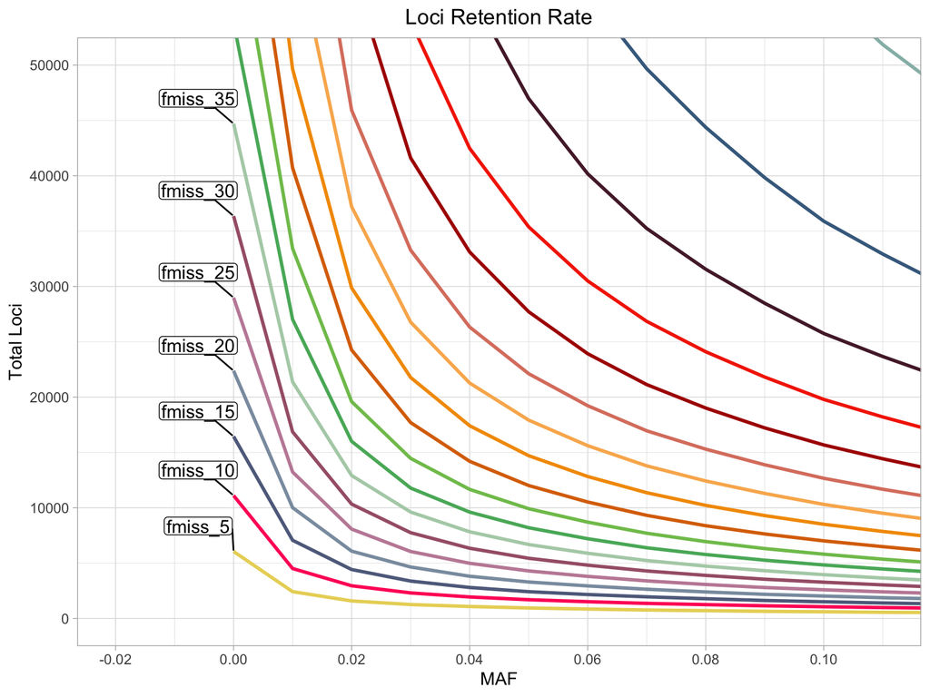

Based on this, going to look at initial PCAs for missingness values of **30** and **20** (i.e. loci retained if they are present in more than 70/80% of individuals) and across the range of **0.01-0.05** MAF. Expecting to be in the range of ~ 3k-16k SNPs for final dataset.

Example of code to create 012 files (will do this for all 10 parameter combinations).

```bash
vcftools \
--vcf PHHA.bithin.q30.i85.maxdp12.recode.vcf \
--max-missing 0.7 \
--maf 0.01
--remove-filtered-all \
--012 \
--out PHHA.bithin.q30.i85.maxdp12.a70.maf01
```

## Allelic missingness <30% (allele in minimum 156 of 222)

#### **MAF = 0.01** (minor allele in >= 3 individuals)

#### **16,901 SNPs**

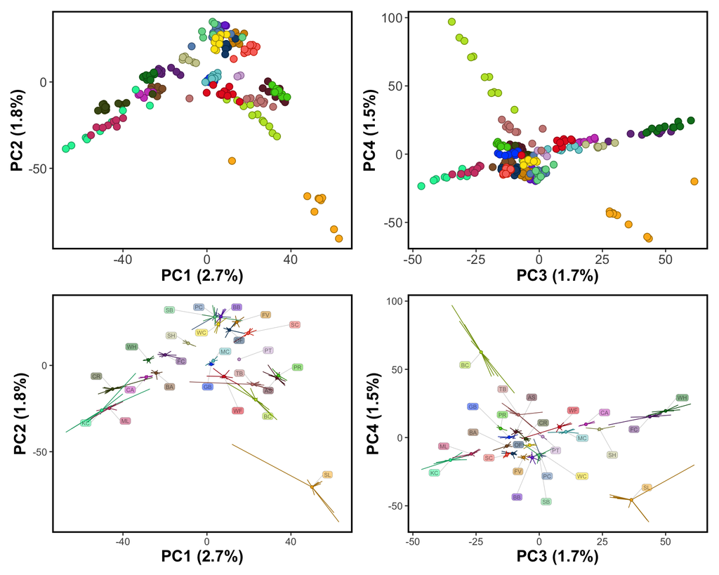

#### **MAF = 0.02** (minor allele in >= 5 individuals)

#### **10,370 SNPs**

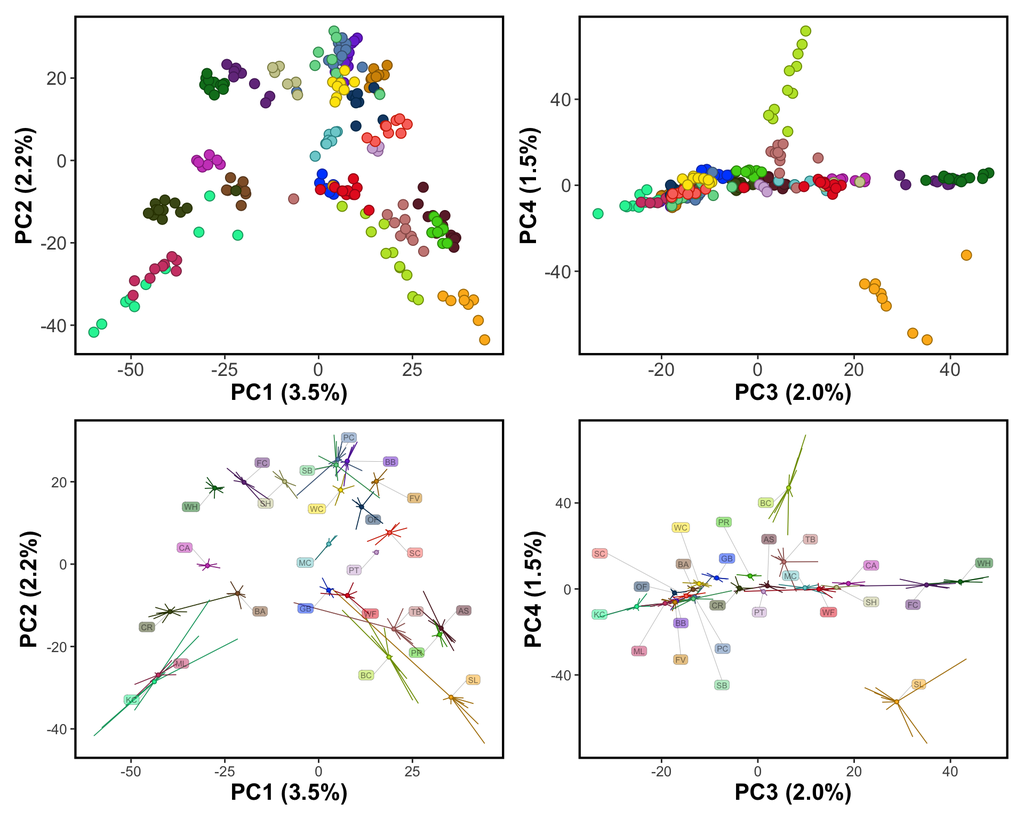

#### **MAF = 0.03** (minor allele in >= 7 individuals)

#### **7,760 SNPs**

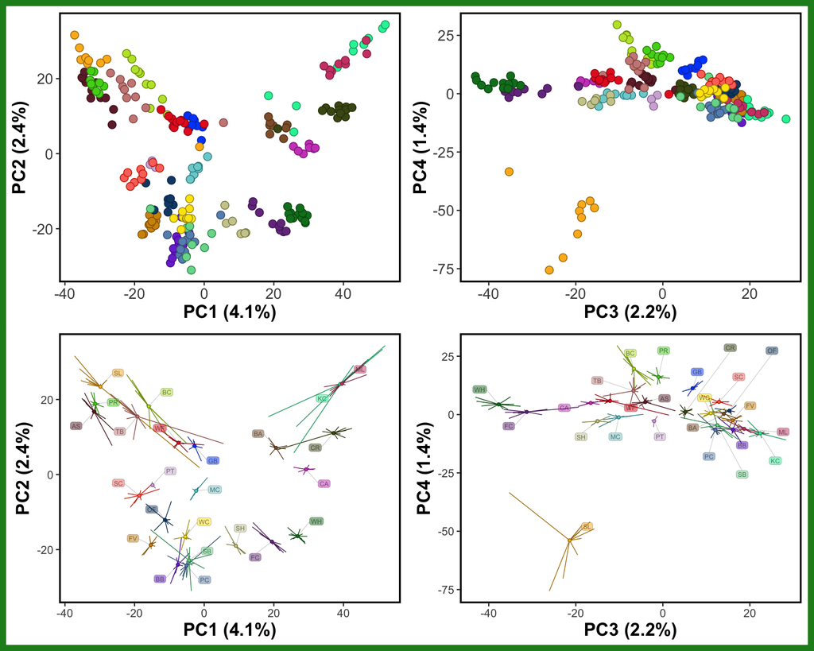

#### **MAF = 0.04** (minor allele in >= 9 individuals)

#### **6,358 SNPs**

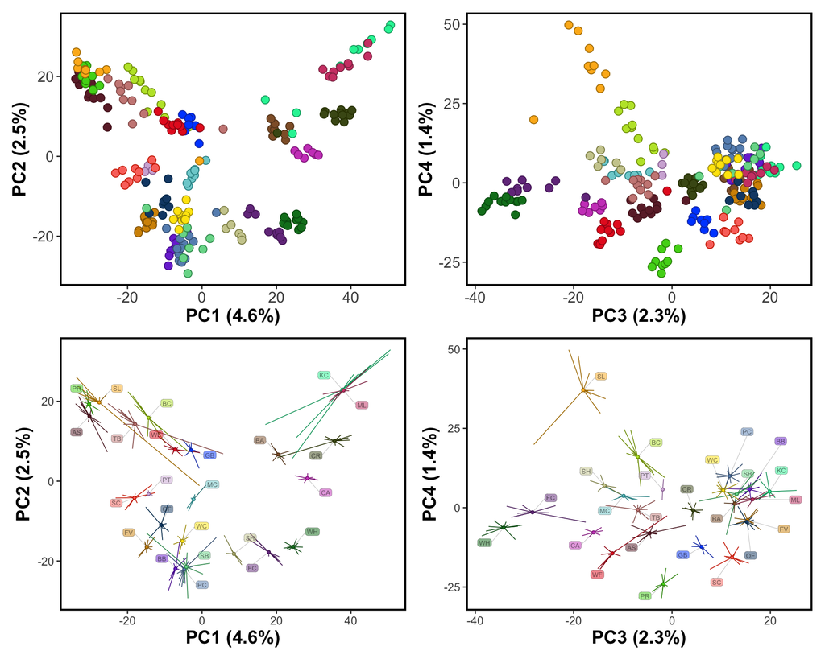

#### **MAF = 0.05** (minor allele in >= 12 individuals)

#### **5,460 SNPs**

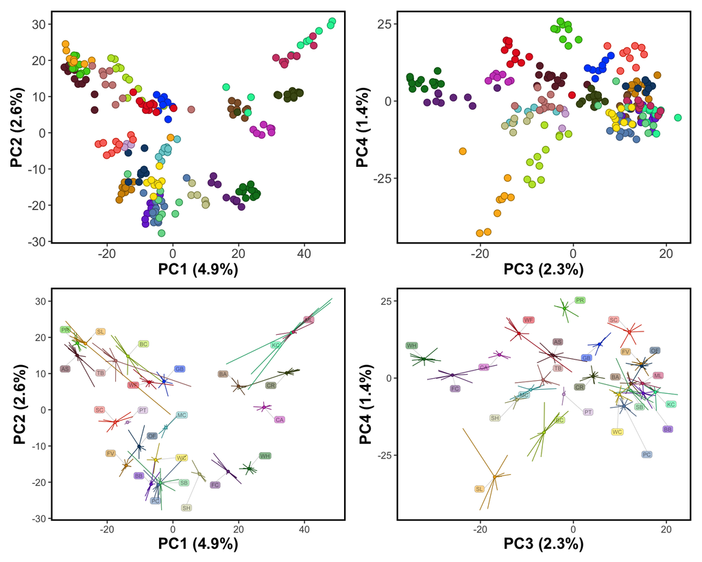

## Allelic missingness <20% (allele in minimum 178 of 222)

#### **MAF = 0.01** (minor allele in >= 3 individuals)

#### **10,053 SNPs**

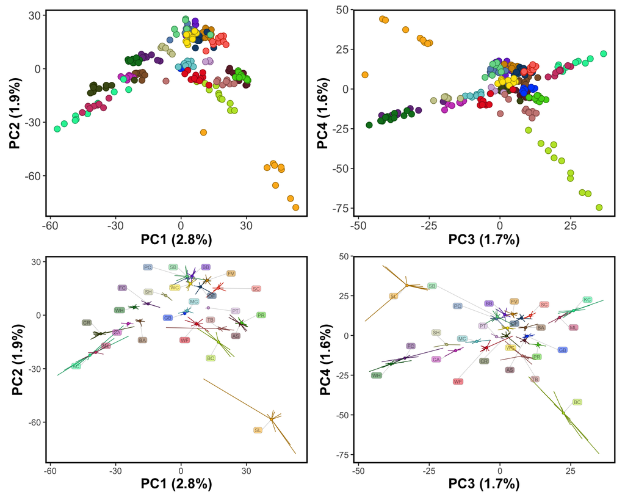

#### **MAF = 0.03** (minor allele in >= 7 individuals)

#### **4,660 SNPs**

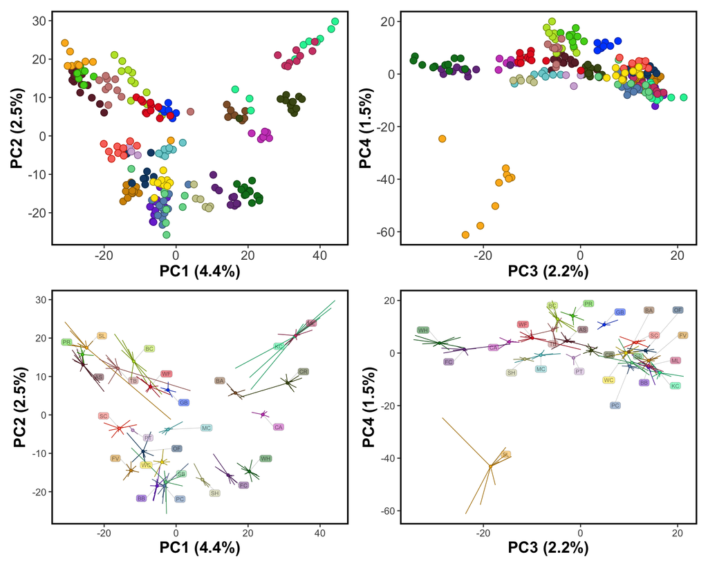

#### **MAF = 0.05** (minor allele in >= 12 individuals)

#### **3,307 SNPs**

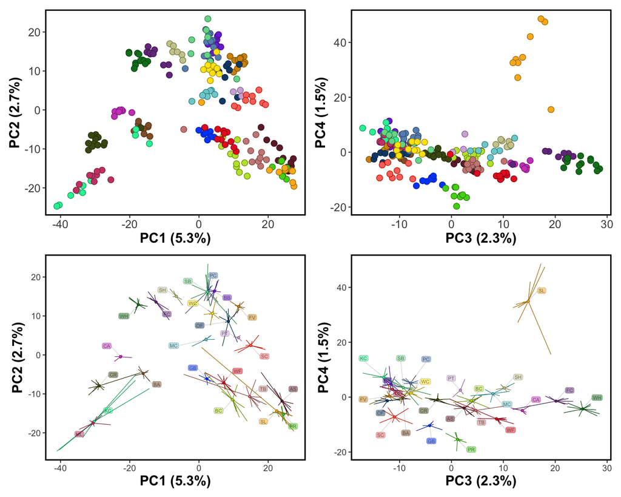

Just want to do some final checks that the filtered sets of SNPs don’t have any weird patterns with coverage or missing data across populations. Need to pull out individual depth and missingness data via:

```bash
vcftools \
--vcf PHHA.bithin.q30.i85.maxdp12.recode.vcf \
--max-missing 0.7 \
--maf 0.01
--remove-filtered-all \
--missing-indv \
--out PHHA.bithin.q30.i85.maxdp12.a70.maf01
```

```bash
vcftools \
--vcf PHHA.bithin.q30.i85.maxdp12.recode.vcf \
--max-missing 0.7 \
--maf 0.01
--remove-filtered-all \
--depth \
--out PHHA.bithin.q30.i85.maxdp12.a70.maf01
```

Above produces files with the suffixes `.imiss` and `.idepth`. Going to look at this across a few different MAF thresholds (0.01, 0.03, 0.05) just to make sure nothing changes.

#### **MAF = 0.01**

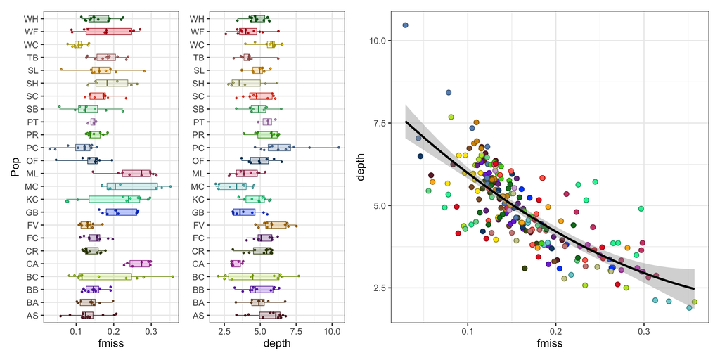

#### **MAF = 0.03**

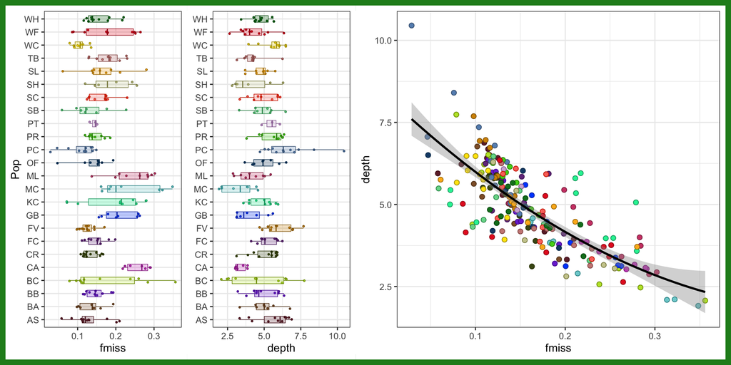

#### **MAF = 0.05**

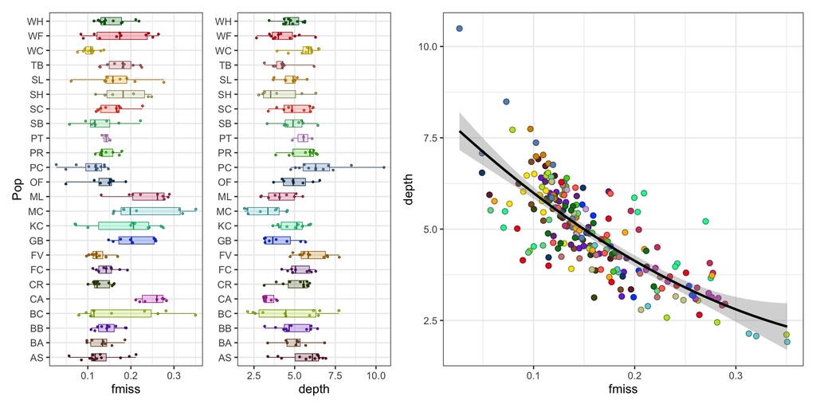

No major changes. Creating a final VCF for entropy via:

```bash
vcftools \
--vcf PHHA.bithin.q30.i85.maxdp12.recode.vcf \
--max-missing 0.7 \
--maf 0.03
--remove-filtered-all \
--recode \
--recode-INFO-all \
--out PHHA.bithin.q30.i85.maxdp12.a70.maf03
```